# Dimensionality Reduction of pizza dataset

Artur Skowroński

13 12 2021

## Introduction

The aim of this article is to use PCA and T-SNE method for dimension reduction of pizza dataset. *PCA* method is appropriate for the data, which especially contains continous or quantitative variables. The goal of PCA is to rotate the coordinate system in such a way as to maximize first the variance of the first coordinate, then the variance of the second coordinate, and so on. The coordinate values thus transformed are called the loads of the generated factors (principal components). *T-SNE* is a non-linear technique primarily used for data exploration and visualizing high-dimensional data (I will expand on this issue later). Compared to PCA (founded in 1933), T-SNE can be considered as a fairly new algorithm (2008).

## Libraries and dataset

```r
# Data Handling
library(tidyverse)

# Visualisation
library(ggplot2)
library(GGally)
library(kableExtra)

# PCA
library(factoextra)
library(FactoMineR)
library(gridExtra)
library(factoextra)
library(pca3d)

# T-SNE
library(Rtsne)
library(scatterplot3d)

# Loading dataset
pizza_org <- read.csv('Pizza.csv')
kable(head(pizza_org)) %>%
  kable_styling(bootstrap_options = c("striped", "hover", "condensed"))
```

| brand | id | mois | prot | fat | ash | sodium | carb | cal |
| --- | --- | --- | --- | --- | --- | --- | --- | --- |
| A | 14069 | 27.82 | 21.43 | 44.87 | 5.11 | 1.77 | 0.77 | 4.93 |
| A | 14053 | 28.49 | 21.26 | 43.89 | 5.34 | 1.79 | 1.02 | 4.84 |
| A | 14025 | 28.35 | 19.99 | 45.78 | 5.08 | 1.63 | 0.80 | 4.95 |
| A | 14016 | 30.55 | 20.15 | 43.13 | 4.79 | 1.61 | 1.38 | 4.74 |
| A | 14005 | 30.49 | 21.28 | 41.65 | 4.82 | 1.64 | 1.76 | 4.67 |
| A | 14075 | 31.14 | 20.23 | 42.31 | 4.92 | 1.65 | 1.40 | 4.67 |

The dataset was downloaded from this link: https://data.world/sdhilip/pizza-datasets and it contains information on the micronutrients of various pizzas.

The variables in the data set are:

- brand - Pizza brand (class label)
- id - Sample analised
- mois - Amount of water per 100 grams in the sample
- prot - Amount of protein per 100 grams in the sample
- fat - Amount of fat per 100 grams in the sample
- ash - Amount of ash per 100 grams in the sample
- sodium - Amount of sodium per 100 grams in the sample
- carb - Amount of carbohydrates per 100 grams in the sample
- cal - Amount of calories per 100 grams in the sample

## Exploratory Data Analysis

Before implementing any Machine Learning algorithm, it is advisable to get know with the data in order to understand it more clearly. In my opinion it is very helpful, because in our future work it is hard to estimate with what kind of data we will have to deal with.

```r
dim(pizza_org)
```

```
## [1] 300   9
```

```r
summary(pizza_org)
```

```
##     brand                 id             mois            prot
##  Length:300         Min.   :14003   Min.   :25.00   Min.   : 6.98
##  Class :character   1st Qu.:14094   1st Qu.:30.90   1st Qu.: 8.06
##  Mode  :character   Median :24021   Median :43.30   Median :10.44
##                     Mean   :20841   Mean   :40.90   Mean   :13.37
##                     3rd Qu.:24110   3rd Qu.:49.12   3rd Qu.:20.02
##                     Max.   :34045   Max.   :57.22   Max.   :28.48
##       fat             ash            sodium            carb
##  Min.   : 4.38   Min.   :1.170   Min.   :0.2500   Min.   : 0.510
##  1st Qu.:14.77   1st Qu.:1.450   1st Qu.:0.4500   1st Qu.: 3.467
##  Median :17.14   Median :2.225   Median :0.4900   Median :23.245
##  Mean   :20.23   Mean   :2.633   Mean   :0.6694   Mean   :22.865
##  3rd Qu.:21.43   3rd Qu.:3.592   3rd Qu.:0.7025   3rd Qu.:41.337
##  Max.   :47.20   Max.   :5.430   Max.   :1.7900   Max.   :48.640
##       cal
##  Min.   :2.180
##  1st Qu.:2.910
##  Median :3.215
##  Mean   :3.271
##  3rd Qu.:3.520
##  Max.   :5.080
```

```r
table(pizza_org$brand)
```

```
##
##  A  B  C  D  E  F  G  H  I  J
## 29 31 27 32 28 30 29 33 29 32
```

Let’s check if there are any NaN values in the dataset.

```r
apply(pizza_org[1:length(colnames(pizza_org))],2, anyNA)
```

```
##  brand     id   mois   prot    fat    ash sodium   carb    cal
##  FALSE  FALSE  FALSE  FALSE  FALSE  FALSE  FALSE  FALSE  FALSE
```

As we see, there are no missing values in our dataset.

#### Id variable

At first let me change the name of “id” variable just into “sample”. It might be good to delve into this variable, because it seems to me that this column should be dropped. That’s why, I will check the uniqness of this column.

```r
colnames(pizza_org)[which(names(pizza_org) == "id")] <- c("sample")
length(unique(pizza_org$sample))
```

```
## [1] 291
```

It occured that the number of unique values is not equal to the number of rows. That’s why, I have to check whether there are some duplicates.

```r
sample_table <- table(pizza_org$sample) == 2
sample_table[sample_table == TRUE]; sum(sample_table[sample_table == TRUE])
```

```
##
## 14029 14044 14045 14126 24035 24043 24049 24089 24110
##  TRUE  TRUE  TRUE  TRUE  TRUE  TRUE  TRUE  TRUE  TRUE
```

```
## [1] 9
```

We see that there are 9 values which potentially might be duplicated - let’s check this records in the dataset.

```r
sample_table_frame <- as.data.frame(sample_table[sample_table == TRUE])
# Set indexes into the first column
sample_table_frame <- cbind(newColName = rownames(sample_table_frame), sample_table_frame)
rownames(sample_table_frame) <- 1:nrow(sample_table_frame)
# Get values of potential duplicates
kable(pizza_org[pizza_org$sample %in% sample_table_frame$newColName,]) %>%
  kable_styling()
```

|  | brand | sample | mois | prot | fat | ash | sodium | carb | cal |
| --- | --- | --- | --- | --- | --- | --- | --- | --- | --- |
| 53 | B | 24049 | 50.87 | 13.85 | 27.64 | 3.71 | 1.10 | 3.93 | 3.20 |
| 66 | C | 14029 | 49.73 | 25.65 | 19.98 | 2.51 | 0.52 | 2.13 | 2.91 |
| 78 | C | 24043 | 52.19 | 26.00 | 16.64 | 4.17 | 0.61 | 1.00 | 2.58 |
| 119 | D | 24043 | 52.19 | 26.00 | 16.64 | 4.17 | 0.61 | 1.00 | 2.58 |
| 125 | E | 14029 | 39.59 | 8.36 | 4.39 | 1.52 | 0.48 | 46.14 | 2.58 |
| 130 | E | 14126 | 37.78 | 8.30 | 13.05 | 1.64 | 0.49 | 39.23 | 3.08 |
| 134 | E | 24110 | 37.34 | 7.33 | 19.61 | 1.60 | 0.45 | 34.12 | 3.42 |
| 137 | E | 24110 | 37.34 | 7.33 | 19.61 | 1.60 | 0.45 | 34.12 | 3.42 |
| 138 | E | 24035 | 34.31 | 7.98 | 14.54 | 1.46 | 0.49 | 41.71 | 3.30 |
| 146 | E | 14126 | 37.78 | 8.30 | 13.05 | 1.64 | 0.49 | 39.23 | 3.08 |
| 162 | F | 24035 | 27.65 | 7.78 | 17.30 | 1.29 | 0.40 | 46.25 | 3.72 |
| 163 | F | 24049 | 28.33 | 7.82 | 17.96 | 1.41 | 0.45 | 44.48 | 3.71 |
| 227 | H | 24089 | 35.74 | 7.86 | 14.27 | 1.40 | 0.44 | 40.73 | 3.23 |
| 239 | H | 24089 | 35.74 | 7.86 | 14.27 | 1.40 | 0.44 | 40.73 | 3.23 |
| 271 | J | 14044 | 47.60 | 10.43 | 15.18 | 2.32 | 0.56 | 24.47 | 2.76 |
| 272 | J | 14045 | 46.84 | 9.91 | 15.50 | 2.27 | 0.57 | 25.48 | 2.81 |
| 299 | J | 14044 | 47.60 | 10.43 | 15.18 | 2.32 | 0.56 | 24.47 | 2.76 |
| 300 | J | 14045 | 46.84 | 9.91 | 15.50 | 2.27 | 0.57 | 25.48 | 2.81 |

Well the result is quite tricky, because some records are 1:1 equal (for example sample no. = 24110). These records can be treated as duplicates. However, for some sample values all the other “nutrient” variables are the same. Interestingly, they have been assigned to the other brands, which bake pizzas (for example sample = 24043).

I am aware that deleting records is not always the best way to perform further analysis. However, I’m not entirely sure how the data was derived and I’m afraid that duplicated data may interfere with my subsequent matches. Nevertheless, for the purposes of this exercise, I decided to remove these records. For the data that differs only in the brand column, I decided to leave it unchanged. I don’t think that they are incorrect. Perhaps there are some pizzerias, which bake 1:1 the same type of pizza.

```r
# Making a copy of original dataset, in order to not having the same memory address
pizza_non_scaled <- data.frame(pizza_org)
pizza_non_sc_no_dp <- pizza_non_scaled[!duplicated(pizza_non_scaled), ]

print(paste("The number of removed rows is equal to:", nrow(pizza_org) - nrow(pizza_non_sc_no_dp)))
```

```
## [1] "The number of removed rows is equal to: 5"
```

Moreover, I will also get rid of sample variable, becasue it seems to me that it does not contribute any additional relevant information about the pizzas.

```r
pizza <- subset(pizza_non_sc_no_dp, select = -c(sample))
kable(head(pizza)) %>%
  kable_styling()
```

| brand | mois | prot | fat | ash | sodium | carb | cal |
| --- | --- | --- | --- | --- | --- | --- | --- |
| A | 27.82 | 21.43 | 44.87 | 5.11 | 1.77 | 0.77 | 4.93 |
| A | 28.49 | 21.26 | 43.89 | 5.34 | 1.79 | 1.02 | 4.84 |
| A | 28.35 | 19.99 | 45.78 | 5.08 | 1.63 | 0.80 | 4.95 |
| A | 30.55 | 20.15 | 43.13 | 4.79 | 1.61 | 1.38 | 4.74 |
| A | 30.49 | 21.28 | 41.65 | 4.82 | 1.64 | 1.76 | 4.67 |
| A | 31.14 | 20.23 | 42.31 | 4.92 | 1.65 | 1.40 | 4.67 |

```r
# Looks good now
```

#### Visualisations

Now, let’s “penetrate” the data and look for some interesting relationships and additional information. This will help me to check, if particular companies make their pizzas with similar nutritional ratios or if there are significant differences from brand to brand.

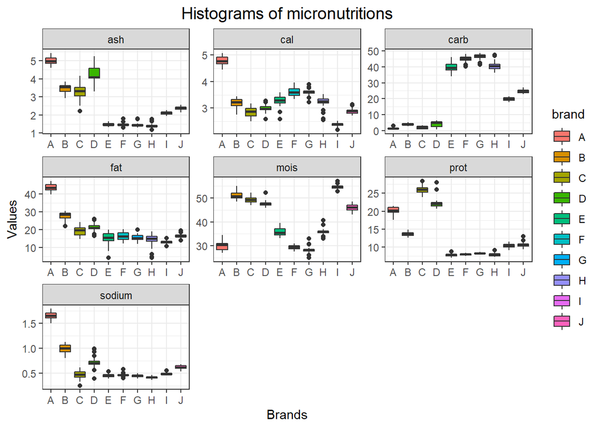

```r
pizza %>%
  gather("micronutritions", "value", 2:8) %>%
  ggplot(aes(x = brand, y = value, fill = brand)) +
    geom_boxplot() +
    ggtitle("Histograms of micronutritions") +
    xlab("Brands") +
    ylab("Values") +
    theme_bw() +
    theme(plot.title = element_text(hjust = 0.5, size = 14)) +
    facet_wrap(~ micronutritions, scales = "free")
```

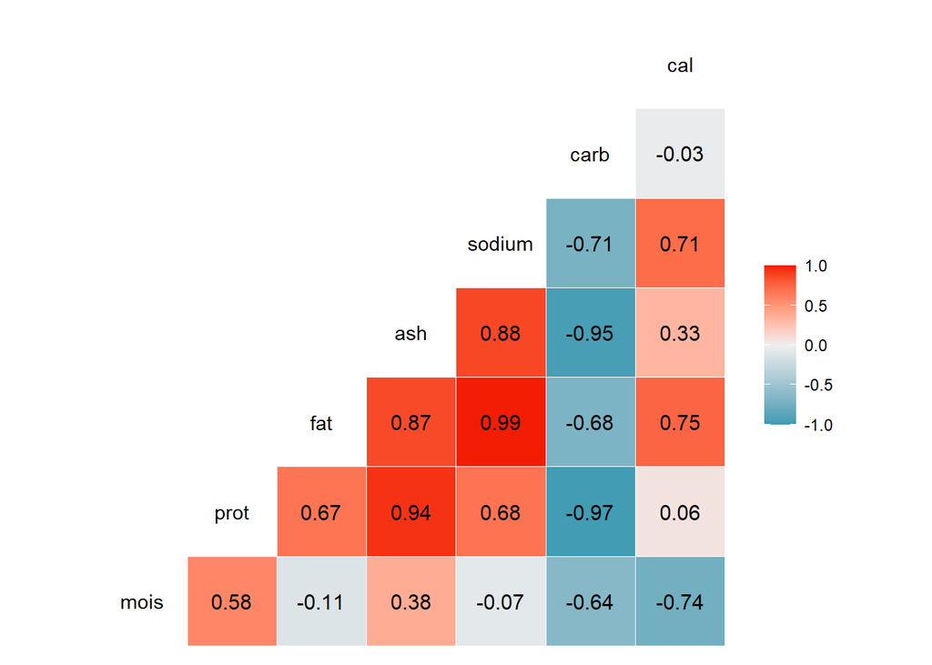

```r
cor_pizza <- cor(pizza[, 2:length(pizza)])
ggcorr(cor_pizza, label = T, label_round = 2)
```

## Dimensions reduction

The aim of this chapter is to implement PCA algorithm, in order to reduce the number of the dimensions. Currently, in my dataset there are 8 different variables, so I think that satisfactory number of components should be lower or equal to 4. Because of the fact that my data is not on the same scale, I will *standardize* the variables wherever it is possible.

#### Kmeans, PAM - optimal number of clusters

Out of curiosity, before running PCA, at first let’s focus on finding the most optimal number of clusters. In order to do that, I will use function factoextra::fviz_nbclust() and apply it into Kmeans and PAM algorithm. Of course, there are some other algorithms of clustering like CLARA, but in my case the dataset is too small, so the results might be unclear.

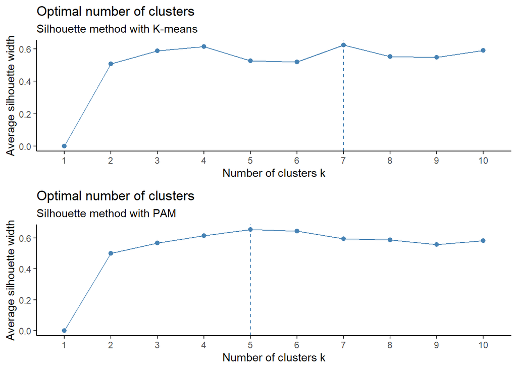

```r
# Scale the data
pizza_scaled <- pizza %>%
              mutate_if(is.numeric, scale)

# Draw optimal number of clusters for Kmeans and PAM
opt_kmeans_sill <- fviz_nbclust(pizza_scaled[,-1], FUNcluster = kmeans, method = "silhouette") + theme_classic() +
  labs(subtitle = "Silhouette method with K-means")
opt_pam_sill <- fviz_nbclust(pizza_scaled[,-1], FUNcluster = cluster::pam, method = "silhouette") + theme_classic() +
  labs(subtitle = "Silhouette method with PAM")
grid.arrange(opt_kmeans_sill, opt_pam_sill, nrow=2)
```

As we see, the optimal number of clusters is different: for kmeans it is 7 clusters, while for PAM it is 5 clusters. As a reminder, it is worth mentioning that the brand variable has 10 unique values.

## PCA

At first let’s implement basic PCA algorithm, in order to see the data will behave.

```r
basic_PCA <- prcomp(pizza[,-1], center = TRUE, scale = TRUE)
summary(basic_PCA)
```

```
## Importance of components:
##                           PC1    PC2     PC3     PC4     PC5     PC6      PC7
## Standard deviation     2.0414 1.5146 0.64461 0.30793 0.16644 0.01841 0.003096
## Proportion of Variance 0.5954 0.3277 0.05936 0.01355 0.00396 0.00005 0.000000
## Cumulative Proportion  0.5954 0.9231 0.98245 0.99599 0.99995 1.00000 1.000000
```

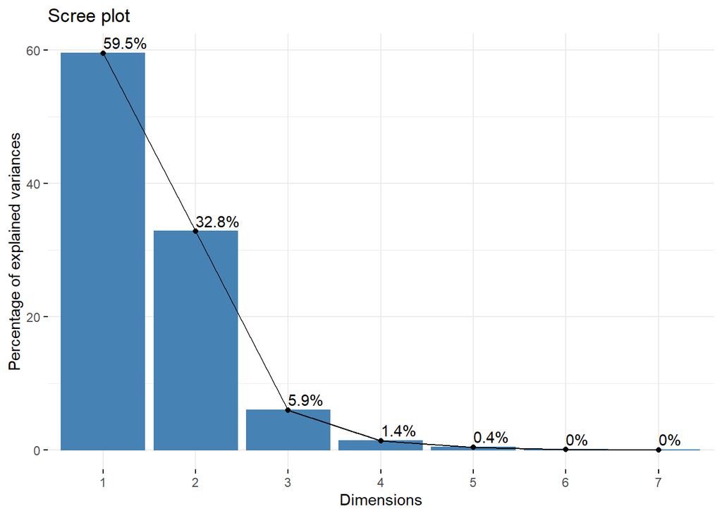

```r
fviz_screeplot(basic_PCA, addlabels = TRUE)
```

As a result, we got 3 different statistic, which describes individual component. The most important, seems to be the variance proportion statistic, because it tells us, how much of the total variance a particular component explains. Of course, we expect that as the number of components increases, the value for this statistic will begin to decrease, which is also seen in the example above. In my case, the PC1 explains 59.54% of the total variance, while the PC2 explains only 32.77%. We can also see that the last 3 components have very little influence on the variance explainability, so intuition hints me that it might be worth trying to reduce the data.

#### Kaiser criterion

I am definitely not satisfied with the number of obtained principal components, so in this case I will dive into my data and try to reduce more dimensions.

There are a lot of tests, which helps to deal with that problem, however I will use the *Kaiser criterion*. This method is based on calculating the eigenvalues. Especially, we are interested in these components for which eigenvalue is **greater than 1**. Having this in mind, let’s check if I am able to improve my “reduction quality”.

```r
pizza_eigen <- factoextra::get_eigenvalue(basic_PCA)
pizza_eigen
```

```
##         eigenvalue variance.percent cumulative.variance.percent
## Dim.1 4.167517e+00     5.953595e+01                    59.53595
## Dim.2 2.294095e+00     3.277279e+01                    92.30874
## Dim.3 4.155157e-01     5.935939e+00                    98.24468
## Dim.4 9.482252e-02     1.354607e+00                    99.59929
## Dim.5 2.770128e-02     3.957325e-01                    99.99502
## Dim.6 3.390803e-04     4.844004e-03                    99.99986
## Dim.7 9.584866e-06     1.369267e-04                   100.00000
```